# lab6

Author

Megan Hoover

#Load libraries for this lab

```r
library(tidyverse)
library(tidymodels)
library(powerjoin)
library(glue)
library(vip)
library(baguette)
library(ggthemes)
library(patchwork)
library(ranger)
library(xgboost)
```

# Download data

```r
root  <- 'https://gdex.ucar.edu/dataset/camels/file'
```

#download the documentation PDF which provides a descriptions for the various columns

```r
download.file('https://gdex.ucar.edu/dataset/camels/file/camels_attributes_v2.0.pdf',
              'data/camels_attributes_v2.0.pdf')
```

# download the .txt files that store the actual data documented in the PDF. Create a vector storing the data types/file names we want to download:

```r
#data from the pdf that we want
types <- c("clim", "geol", "soil", "topo", "vege", "hydro")
```

# Using glue, we can construct the needed URLs and file names for the data we want to download:

```r
# Where the files live online ...
remote_files  <- glue('{root}/camels_{types}.txt')
# where we want to download the data ...
local_files   <- glue('data/camels_{types}.txt')
```

# Now we can download the data: walk2 comes from the purrr package and is used to apply a function to multiple arguments in parallel (much like map2 works over paired lists). Here, we are asking walk2 to pass the first element of remote_files and the first element of local_files to the download.file function to download the data, and setting quiet = TRUE to suppress output. The process is then iterated for the second element of each vector, and so on.

```r
walk2(remote_files, local_files, download.file, quiet = TRUE)
```

# Once downloaded, the data can be read it into R using readr::read_delim(), again instead of applying this to each file individually, we can use map to apply the function to each element of the local_files list.

```r
# Read and merge data
camels <- map(local_files, read_delim, show_col_types = FALSE)
```

# This gives us a list of data.frames, one for each file that we want to merge into a single table. So far in class we have focused on *_join functions to merge data based on a primary and foreign key relationship. In this current list, we have >2 tables, but, have a shared column called gauge_id that we can use to merge the data. However, since we have more then a left and right hand table, we need a more robust tool. We will use the powerjoin package to merge the data into a single data frame. powerjoin is a flexible package for joining lists of data.frames. It provides a wide range of join types, including inner, left, right, full, semi, anti, and cross joins making it a versatile tool for data manipulation and analysis, and one that should feel familiar to users of dplyr.

we are join to merge every data.frame in the list (n = 6) by the shared gauge_id column. Since we want to keep all data, we want a full join.

```r
camels <- power_full_join(camels ,by = 'gauge_id')
```

** Alternatively, we could have read straight from the urls. Strongly consider the implications of this approach as the longevity and persistence of the data is not guaranteed.

Read and merge data: camels <- map(remote_files, read_delim, show_col_types = FALSE) |> power_full_join(by = ‘gauge_id’)

# Q1: From the documentation PDF, report what zero_q_freq represents

There’s nothing in the pdf?

# Exploratory Data Analysis

## first, lets make a map of the sites. Use the borders() ggplot function to add state boundaries to the map and initially color the points by the mean flow (q_mean) at each site.

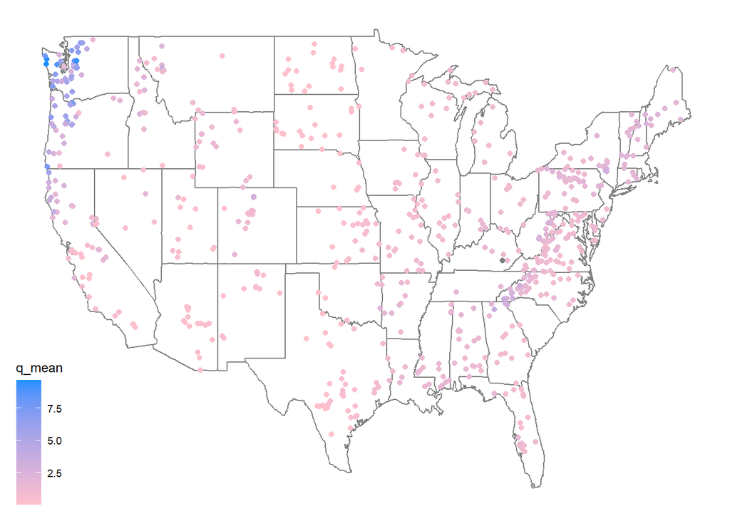

```r
ggplot(data = camels, aes(x = gauge_lon, y = gauge_lat)) +
  borders("state", colour = "gray50") +
  geom_point(aes(color = q_mean)) +
  scale_color_gradient(low = "pink", high = "dodgerblue") +
  ggthemes::theme_map()
```

** scales can be used to map data values to colors (scale_color_*) or fill aesthetics (scale_fill_*). There are two main types of color scales:

Discrete color scales – for things that are categories, like “apples,” “bananas,” and “cherries.” Each gets its own separate color. scale_color_manual(values = c(“red”, “yellow”, “pink”)) #lets you pick your own colors.

Or

scale_color_brewer(palette = “Set1”) #uses a built-in color set.

Continuous color scales – for numbers, like temperature (cold to hot) or height (short to tall). The color changes smoothly. scale_color_gradient(low = “blue”, high = “red”) #makes small numbers blue and big numbers red.

# Q2: Make 2 maps of the sites, coloring the points by the aridty and p_mean column;

add clear labels, titles, and a color scale that makes sense for each parameter. Ensure these render as a single image with your choice of facet_*, patchwork, or ggpubr

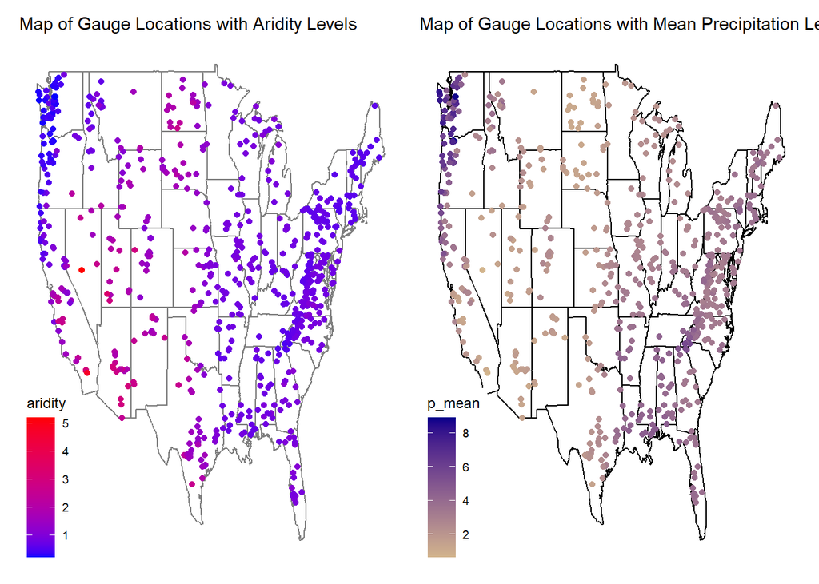

```r
#map of aridity
aridity_plot<-ggplot(data = camels, aes(x = gauge_lon, y = gauge_lat)) +
  borders("state", colour = "gray50") +
  geom_point(aes(color = aridity)) +
  scale_color_gradient(low = "blue", high = "red") +
  ggthemes::theme_map() +
  ggtitle("Map of Gauge Locations with Aridity Levels") +  # Title
  xlab("Longitude") +  # X-axis label
  ylab("Latitude")     # Y-axis label

#map of p_mean
p_meanplot<-ggplot(data = camels, aes(x = gauge_lon, y = gauge_lat)) +
  borders("state", colour = "black") +
  geom_point(aes(color = p_mean)) +
  scale_color_gradient(low = "tan", high = "darkblue") +
  ggthemes::theme_map() +
  ggtitle("Map of Gauge Locations with Mean Precipitation Levels") +  # Title
  xlab("Longitude") +  # X-axis label
  ylab("Latitude")     # Y-axis label

# Combine the two maps into a single image using patchwork
aridity_plot | p_meanplot
```

## Model Preparation

# As an initial analysis, lets look at the relationship between aridity, rainfall and mean flow. First, lets make sure there is not significant correlation between these variables. Here, we make sure to drop NAs and only view the 3 columns of interest.

```r
#given code to run
camels |>
  select(aridity, p_mean, q_mean) |>
  drop_na() |>
  cor()
```

```
           aridity     p_mean     q_mean
aridity  1.0000000 -0.7550090 -0.5817771
p_mean  -0.7550090  1.0000000  0.8865757
q_mean  -0.5817771  0.8865757  1.0000000
```

As expected, there is a strong correlation between rainfall and mean flow, and an inverse correlation between aridity and rainfall. While both are high, we are going see if we can build a model to predict mean flow using aridity and rainfall.

# Visual EDA

## Lets start by looking that the 3 dimensions (variables) of this data. We’ll start with a XY plot of aridity and rainfall. We are going to use the scale_color_viridis_c() function to color the points by the q_mean column. This scale functions maps the color of the points to the values in the q_mean column along the viridis continuous (c) palette. Because a scale_color_* function is applied, it maps to the known color aesthetic in the plot.

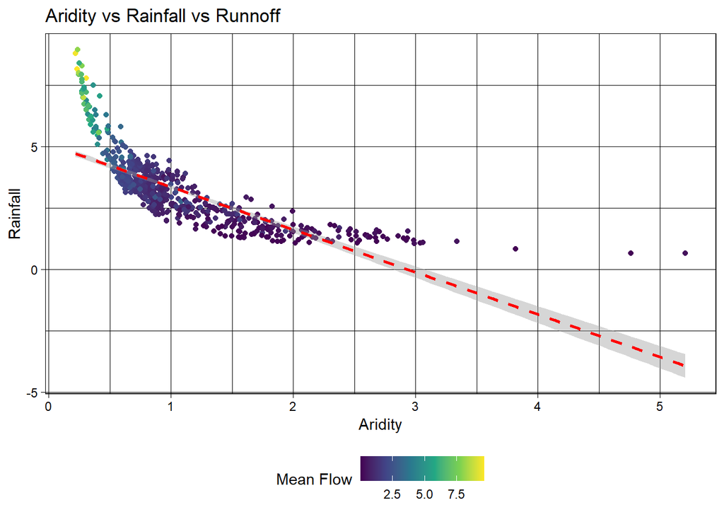

```r
# Create a scatter plot of aridity vs rainfall
ggplot(camels, aes(x = aridity, y = p_mean)) +
  # Add points colored by mean flow
  geom_point(aes(color = q_mean)) +
  # Add a linear regression line
  geom_smooth(method = "lm", color = "red", linetype = 2) +
  # Apply the viridis color scale
  scale_color_viridis_c() +
  # Add a title, axis labels, and theme (w/ legend on the bottom)
  theme_linedraw() +
  theme(legend.position = "bottom") +
  labs(title = "Aridity vs Rainfall vs Runnoff",
       x = "Aridity",
       y = "Rainfall",
       color = "Mean Flow")
```

# Ok! so it looks like there is a relationship between rainfall, aridity, and rainfall but it looks like an exponential decay function and is certainly not linear.

To test a transformation, we can log transform the x and y axes using the scale_x_log10() and scale_y_log10() functions:

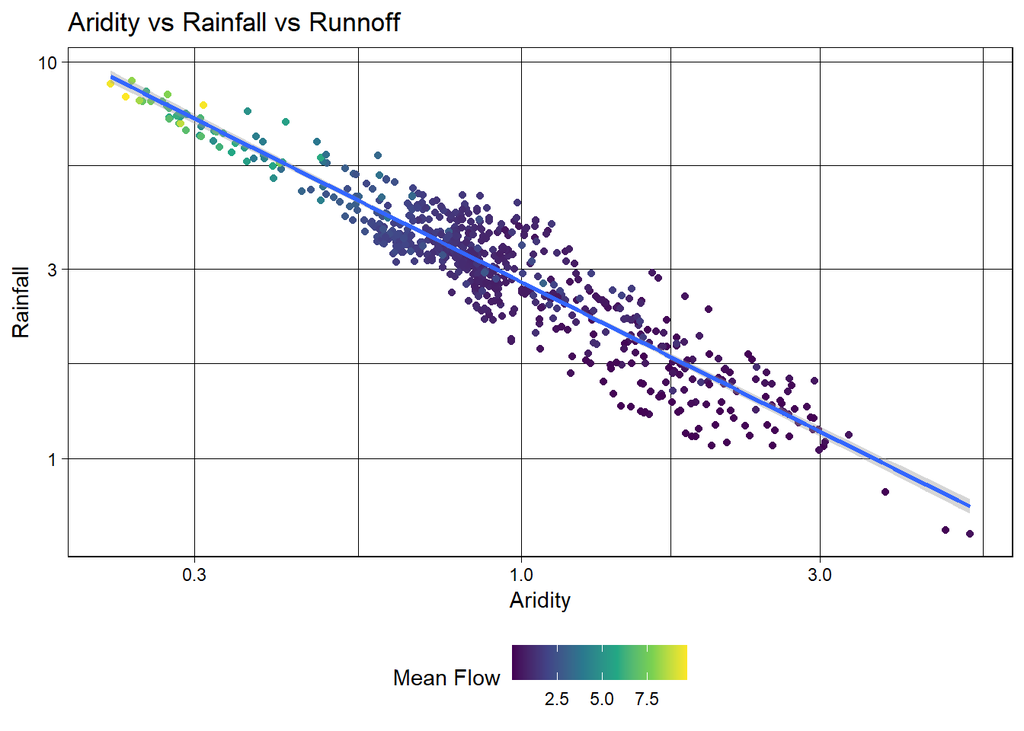

```r
ggplot(camels, aes(x = aridity, y = p_mean)) +
  geom_point(aes(color = q_mean)) +
  geom_smooth(method = "lm") +
  scale_color_viridis_c() +
  # Apply log transformations to the x and y axes
  scale_x_log10() +
  scale_y_log10() +
  theme_linedraw() +
  theme(legend.position = "bottom") +
  labs(title = "Aridity vs Rainfall vs Runnoff",
       x = "Aridity",
       y = "Rainfall",
       color = "Mean Flow")
```

# Great! We can see a log-log relationship between aridity and rainfall provides a more linear relationship. This is a common relationship in hydrology and is often used to estimate rainfall in ungauged basins. However, once the data is transformed, the lack of spread in the streamflow data is quite evident with high mean flow values being compressed to the low end of aridity/high end of rainfall.

To address this, we can visualize how a log transform may benifit the q_mean data as well. Since the data is represented by color, rather then an axis, we can use the trans (transform) argument in the scale_color_viridis_c() function to log transform the color scale:

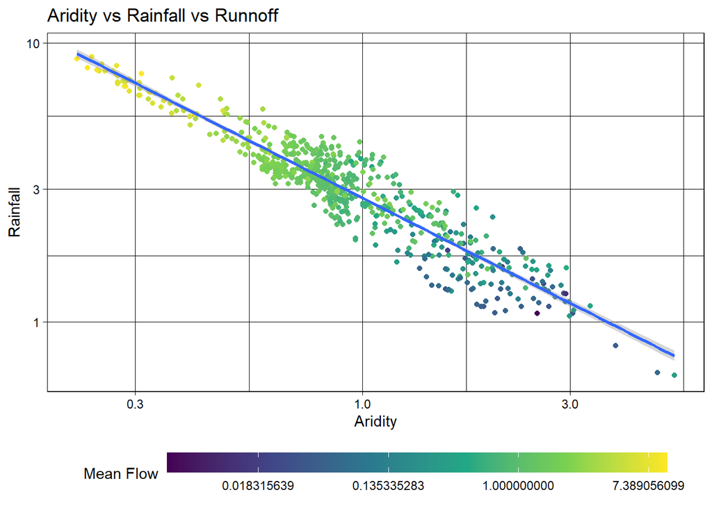

```r
ggplot(camels, aes(x = aridity, y = p_mean)) +
  geom_point(aes(color = q_mean)) +
  geom_smooth(method = "lm") +
  # Apply a log transformation to the color scale
  scale_color_viridis_c(trans = "log") +
  scale_x_log10() +
  scale_y_log10() +
  theme_linedraw() +
  theme(legend.position = "bottom",
        # Expand the legend width ...
        legend.key.width = unit(2.5, "cm"),
        legend.key.height = unit(.5, "cm")) +
  labs(title = "Aridity vs Rainfall vs Runnoff",
       x = "Aridity",
       y = "Rainfall",
       color = "Mean Flow")
```

# Excellent! Treating these three right skewed variables as log transformed, we can see a more evenly spread relationship between aridity, rainfall, and mean flow. This is a good sign for building a model to predict mean flow using aridity and rainfall.

## Model Building

# Let’s split the data:

First, we set a seed for reproducabilty, then transform the q_mean column to a log scale. Remember it is error prone to apply transformations to the outcome variable within a recipe. So, we’ll do it a prioi.

Once set, we can split the data into a training and testing set. We are going to use 80% of the data for training and 20% for testing with no stratification.

Additionally, we are going to create a 10-fold cross validation dataset to help us evaluate multi-model setups.

```r
set.seed(123)
# Bad form to perform simple transformations on the outcome variable within a
# recipe. So, we'll do it here.
camels <- camels |>
  mutate(logQmean = log(q_mean))

# Generate the split
camels_split <- initial_split(camels, prop = 0.8)
camels_train <- training(camels_split)
camels_test  <- testing(camels_split)

camels_cv <- vfold_cv(camels_train, v = 10)
```

## Preprocessor: recipe

# In lecture, we have focused on using formulas as a workflow preprocessor. Separately we have used the recipe function to define a series of data preprocessing steps. Here, we are going to use the recipe function to define a series of data preprocessing steps.

We learned quite a lot about the data in the visual EDA. We know that the q_mean, aridity and p_mean columns are right skewed and can be helped by log transformations. We also know that the relationship between aridity and p_mean is non-linear and can be helped by adding an interaction term to the model. To implement these, lets build a recipe!

```r
# Create a recipe to preprocess the data
rec <-  recipe(logQmean ~ aridity + p_mean, data = camels_train) %>%
  # Log transform the predictor variables (aridity and p_mean)
  step_log(all_predictors()) %>%
  # Add an interaction term between aridity and p_mean
  step_interact(terms = ~ aridity:p_mean) |>
  # Drop any rows with missing values in the pred
  step_naomit(all_predictors(), all_outcomes())
```

## Naive base lm approach

# Ok, to start, lets do what we are comfortable with … fitting a linear model to the data. First, we use prep and bake on the training data to apply the recipe. Then, we fit a linear model to the data.

```r
# Prepare the data
baked_data <- prep(rec, camels_train) |>
  bake(new_data = NULL)

# Interaction with lm
#  Base lm sets interaction terms with the * symbol
lm_base <- lm(logQmean ~ aridity * p_mean, data = baked_data)
summary(lm_base)
```

```
Call:
lm(formula = logQmean ~ aridity * p_mean, data = baked_data)

Residuals:
     Min       1Q   Median       3Q      Max
-2.91162 -0.21601 -0.00716  0.21230  2.85706

Coefficients:
               Estimate Std. Error t value Pr(>|t|)
(Intercept)    -1.77586    0.16365 -10.852  < 2e-16 ***
aridity        -0.88397    0.16145  -5.475 6.75e-08 ***
p_mean          1.48438    0.15511   9.570  < 2e-16 ***
aridity:p_mean  0.10484    0.07198   1.457    0.146
---
Signif. codes:  0 '***' 0.001 '**' 0.01 '*' 0.05 '.' 0.1 ' ' 1

Residual standard error: 0.5696 on 531 degrees of freedom
Multiple R-squared:  0.7697,    Adjusted R-squared:  0.7684
F-statistic: 591.6 on 3 and 531 DF,  p-value: < 2.2e-16
```

```r
# Sanity Interaction term from recipe ... these should be equal!!
summary(lm(logQmean ~ aridity + p_mean + aridity_x_p_mean, data = baked_data))
```

```
Call:
lm(formula = logQmean ~ aridity + p_mean + aridity_x_p_mean,
    data = baked_data)

Residuals:
     Min       1Q   Median       3Q      Max
-2.91162 -0.21601 -0.00716  0.21230  2.85706

Coefficients:
                 Estimate Std. Error t value Pr(>|t|)
(Intercept)      -1.77586    0.16365 -10.852  < 2e-16 ***
aridity          -0.88397    0.16145  -5.475 6.75e-08 ***
p_mean            1.48438    0.15511   9.570  < 2e-16 ***
aridity_x_p_mean  0.10484    0.07198   1.457    0.146
---
Signif. codes:  0 '***' 0.001 '**' 0.01 '*' 0.05 '.' 0.1 ' ' 1

Residual standard error: 0.5696 on 531 degrees of freedom
Multiple R-squared:  0.7697,    Adjusted R-squared:  0.7684
F-statistic: 591.6 on 3 and 531 DF,  p-value: < 2.2e-16
```

## Where things get a little messy…

# Ok so now we have our trained model lm_base and want to validate it on the test data.

Remember a models ability to predict on new data is the most important part of the modeling process. It really doesnt matter how well it does on data it has already seen!

We have to be careful about how we do this with the base R approach:

## Wrong version 1: augment

# The broom package provides a convenient way to extract model predictions and residuals. We can use the augment function to add predicted values to the test data. However, if we use augment directly on the test data, we will get incorrect results because the preprocessing steps defined in the recipe object have not been applied to the test data.

```r
nrow(camels_test)
```

```
[1] 135
```

```r
nrow(camels_train)
```

```
[1] 536
```

```r
# run to verify doesn't work --> broom::augment(lm_base, data = camels_test)
```

## Wrong version 2: predict

# The predict function can be used to make predictions on new data. However, if we use predict directly on the test data, we will get incorrect results because the preprocessing steps defined in the recipe object have not been applied to the test data.

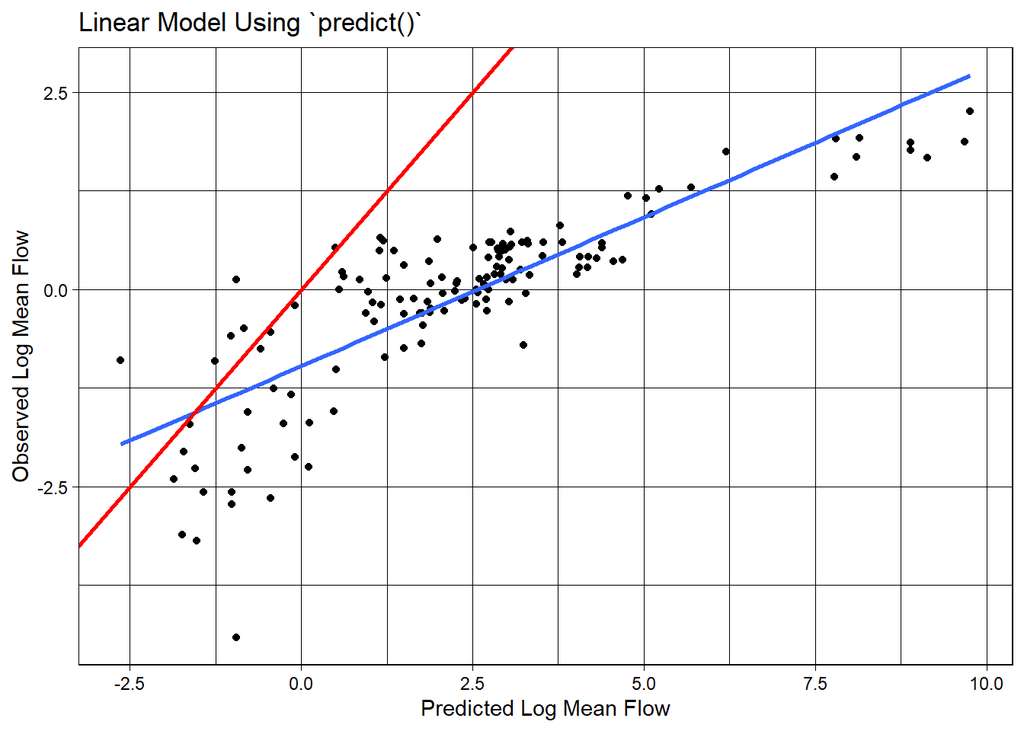

```r
camels_test$p2 = predict(lm_base, newdata = camels_test)

## Scales way off!
ggplot(camels_test, aes(x = p2, y = logQmean)) +
  geom_point() +
  # Linear fit line
  geom_smooth(method = "lm", se = FALSE, size =1) +
  # 1:1 line
  geom_abline(color = "red", size = 1) +
  labs(title = "Linear Model Using `predict()`",
       x = "Predicted Log Mean Flow",
       y = "Observed Log Mean Flow") +
  theme_linedraw()
```

## Correct version: prep -> bake -> predict

# To correctly evaluate the model on the test data, we need to apply the same preprocessing steps to the test data that we applied to the training data. We can do this using the prep and bake functions with the recipe object. This ensures the test data is transformed in the same way as the training data before making predictions.

```r
test_data <-  bake(prep(rec), new_data = camels_test)
test_data$lm_pred <- predict(lm_base, newdata = test_data)
```

## Model Evaluation: statistical and visual

# Now that we have the predicted values, we can evaluate the model using the metrics function from the yardstick package. This function calculates common regression metrics such as RMSE, R-squared, and MAE between the observed and predicted values.

```r
metrics(test_data, truth = logQmean, estimate = lm_pred)
```

```
# A tibble: 3 × 3
  .metric .estimator .estimate
  <chr>   <chr>          <dbl>
1 rmse    standard       0.583
2 rsq     standard       0.742
3 mae     standard       0.390
```

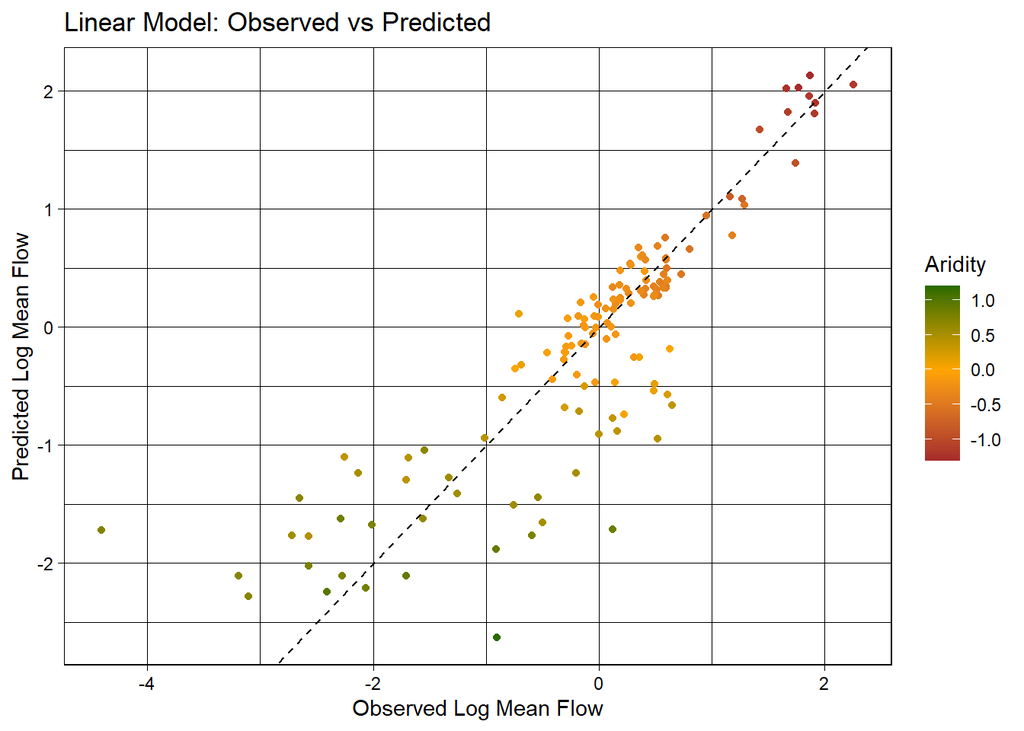

```r
ggplot(test_data, aes(x = logQmean, y = lm_pred, colour = aridity)) +
  # Apply a gradient color scale
  scale_color_gradient2(low = "brown", mid = "orange", high = "darkgreen") +
  geom_point() +
  geom_abline(linetype = 2) +
  theme_linedraw() +
  labs(title = "Linear Model: Observed vs Predicted",
       x = "Observed Log Mean Flow",
       y = "Predicted Log Mean Flow",
       color = "Aridity")
```

Ok so that was a bit burdensome, is really error prone (fragile), and is worthless if we wanted to test a different algorithm… lets look at a better approach!

## Using a workflow instead

# tidymodels provides a framework for building and evaluating models using a consistent and modular workflow. The workflows package allows you to define a series of modeling steps, including data preprocessing, model fitting, and model fitting, in a single object. This makes it easier to experiment with different models, compare performance, and ensure reproducibility.

workflows are built from a model, a preprocessor, and a execution. Here, we are going to use the linear_reg function to define a linear regression model, set the engine to lm, and the mode to regression. We then add our recipe to the workflow, fit the model to the training data, and extract the model coefficients.

```r
# Define model
lm_model <- linear_reg() %>%
  # define the engine
  set_engine("lm") %>%
  # define the mode
  set_mode("regression")

# Instantiate a workflow ...
lm_wf <- workflow() %>%
  # Add the recipe
  add_recipe(rec) %>%
  # Add the model
  add_model(lm_model) %>%
  # Fit the model to the training data
  fit(data = camels_train)

# Extract the model coefficients from the workflow
summary(extract_fit_engine(lm_wf))$coefficients
```

```
                   Estimate Std. Error    t value     Pr(>|t|)
(Intercept)      -1.7758557 0.16364755 -10.851710 6.463654e-25
aridity          -0.8839738 0.16144589  -5.475357 6.745512e-08
p_mean            1.4843771 0.15511117   9.569762 4.022500e-20
aridity_x_p_mean  0.1048449 0.07198145   1.456555 1.458304e-01
```

Lets ensure we replicated the results from the lm_base model. How do they look to you?

```r
# From the base implementation
summary(lm_base)$coefficients
```

```
                 Estimate Std. Error    t value     Pr(>|t|)
(Intercept)    -1.7758557 0.16364755 -10.851710 6.463654e-25
aridity        -0.8839738 0.16144589  -5.475357 6.745512e-08
p_mean          1.4843771 0.15511117   9.569762 4.022500e-20
aridity:p_mean  0.1048449 0.07198145   1.456555 1.458304e-01
```

They look similar!

## Making Predictions

# Now that lm_wf is a workflow, data is not embedded in the model, we can use augment with the new_data argument to make predictions on the test data.

```r
lm_data <- augment(lm_wf, new_data = camels_test)
dim(lm_data)
```

```
[1] 135  62
```

## Model Evaluation: statistical and visual

# As with EDA, applying for graphical and statistical evaluation of the model is a key Here, we use the metrics function to extract the default metrics (rmse, rsq, mae) between the observed and predicted mean streamflow values.

We then create a scatter plot of the observed vs predicted values, colored by aridity, to visualize the model performance.

```r
metrics(lm_data, truth = logQmean, estimate = .pred)
```

```
# A tibble: 3 × 3
  .metric .estimator .estimate
  <chr>   <chr>          <dbl>
1 rmse    standard       0.583
2 rsq     standard       0.742
3 mae     standard       0.390
```

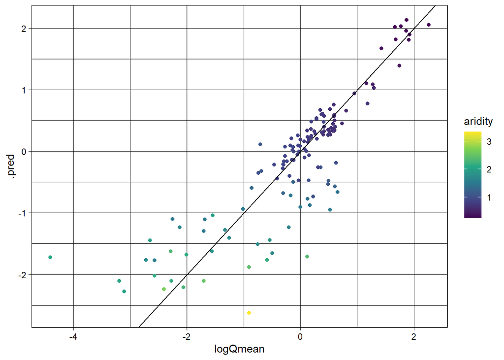

```r
ggplot(lm_data, aes(x = logQmean, y = .pred, colour = aridity)) +
  scale_color_viridis_c() +
  geom_point() +
  geom_abline() +
  theme_linedraw()
```

## Switch it up!

# The real power of this approach is that we can easily switch out the models/recipes and see how it performs. Here, we are going to instead use a random forest model to predict mean streamflow. We define a random forest model using the rand_forest function, set the engine to ranger, and the mode to regression. We then add the recipe, fit the model, and evaluate the skill.

```r
library(baguette)
rf_model <- rand_forest() %>%
  set_engine("ranger", importance = "impurity") %>%
  set_mode("regression")

rf_wf <- workflow() %>%
  # Add the recipe
  add_recipe(rec) %>%
  # Add the model
  add_model(rf_model) %>%
  # Fit the model
  fit(data = camels_train)
```

## Predictions

# Make predictions on the test data using the augment function and the new_data argument.

```r
rf_data <- augment(rf_wf, new_data = camels_test)
dim(rf_data)
```

```
[1] 135  61
```

## Model Evaluation: statistical and visual

# Evaluate the model using the metrics function and create a scatter plot of the observed vs predicted values, colored by aridity.

```r
metrics(rf_data, truth = logQmean, estimate = .pred)
```

```
# A tibble: 3 × 3
  .metric .estimator .estimate
  <chr>   <chr>          <dbl>
1 rmse    standard       0.596
2 rsq     standard       0.733
3 mae     standard       0.370
```

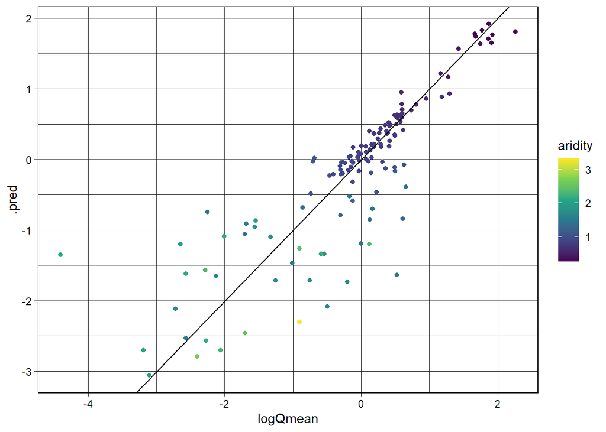

```r
ggplot(rf_data, aes(x = logQmean, y = .pred, colour = aridity)) +
  scale_color_viridis_c() +
  geom_point() +
  geom_abline() +
  theme_linedraw()
```

Awesome! We just set up a completely new model and were able to utilize all of the things we had done for the linear model. This is the power of the tidymodels framework!

That said, we still can reduce some to the repetition. Further, we are not really able to compare these models to one another

## A workflowset approach

# workflow_set is a powerful tool for comparing multiple models on the same data. It allows you to define a set of workflows, fit them to the same data, and evaluate their performance using a common metric. Here, we are going to create a workflow_set object with the linear regression and random forest models, fit them to the training data, and compare their performance using the autoplot and rank_results functions.

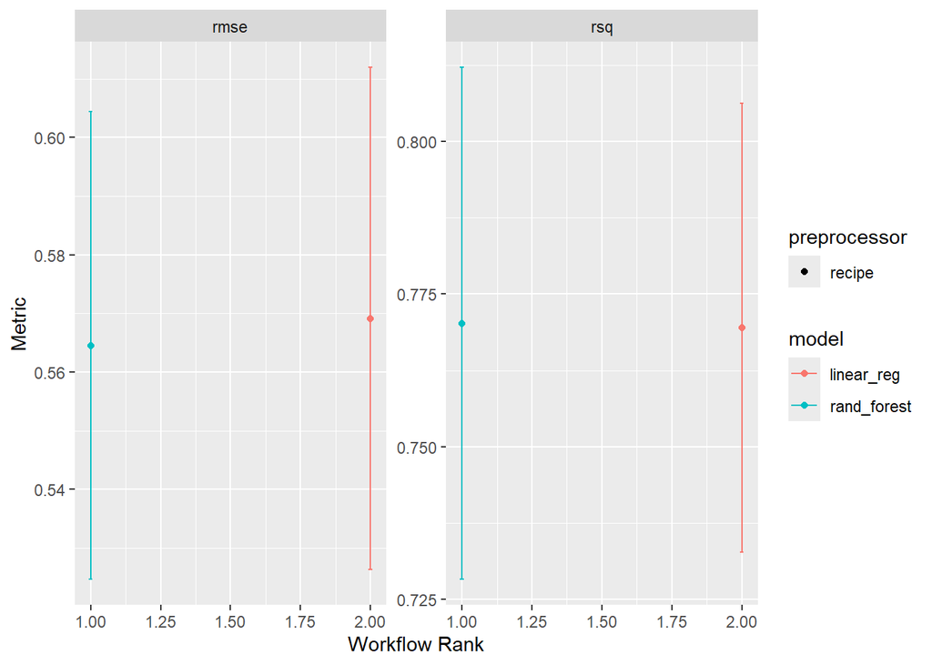

```r
wf <- workflow_set(list(rec), list(lm_model, rf_model)) %>%
  workflow_map('fit_resamples', resamples = camels_cv)

autoplot(wf)
```

```r
rank_results(wf, rank_metric = "rsq", select_best = TRUE)
```

```
# A tibble: 4 × 9
  wflow_id          .config .metric  mean std_err     n preprocessor model  rank
  <chr>             <chr>   <chr>   <dbl>   <dbl> <int> <chr>        <chr> <int>
1 recipe_rand_fore… Prepro… rmse    0.565  0.0243    10 recipe       rand…     1
2 recipe_rand_fore… Prepro… rsq     0.770  0.0255    10 recipe       rand…     1
3 recipe_linear_reg Prepro… rmse    0.569  0.0260    10 recipe       line…     2
4 recipe_linear_reg Prepro… rsq     0.770  0.0223    10 recipe       line…     2
```

## Question 3: Your Turn!

# 1. Build a xgboost (engine) regression (mode) model using boost_tree.

2. Build a neural network model using the nnet engine from the baguette package using the bag_mlp function.
3. Add this to the above workflow.
4. Evaluate the model and compare it to the linear and random forest models.
5. Which of the 4 models would you move forward with?

```r
#define model
boost_model <- boost_tree() %>%
  # define the engine
  set_engine("xgboost") %>%
  # define the mode
  set_mode("regression")
```

```r
#define model
bag_model <- bag_mlp() %>%
  # define the engine
  set_engine("nnet") %>%
  # define the mode
  set_mode("regression")
```

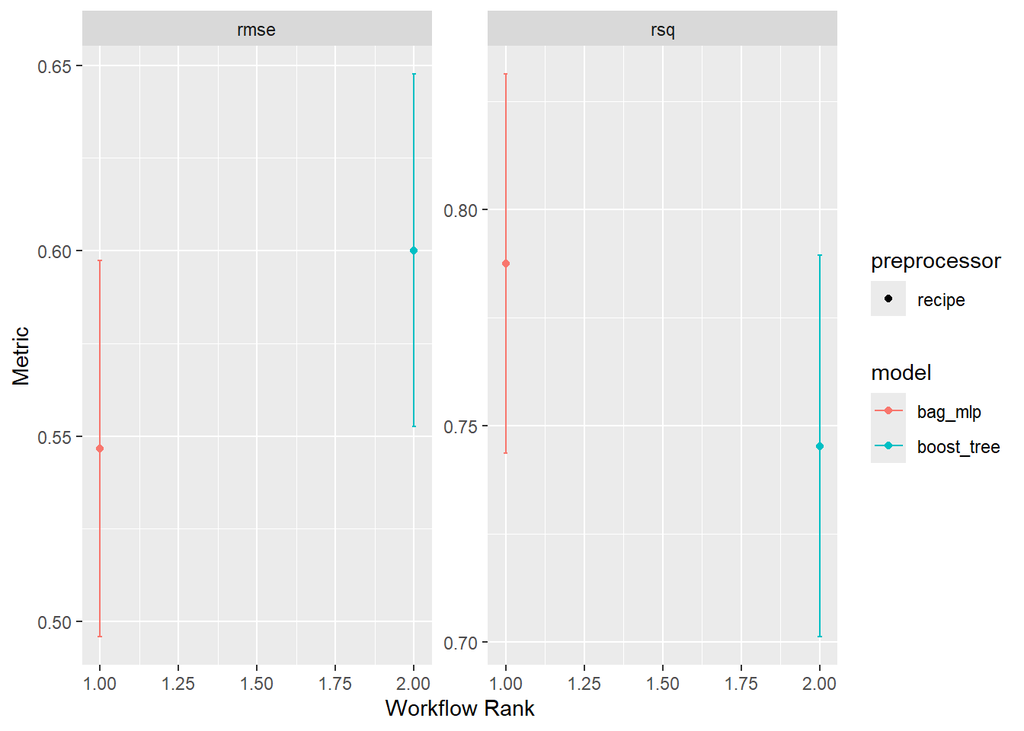

```r
wf_bag_boost <- workflow_set(list(rec), list(bag_model, boost_model)) %>%
  workflow_map('fit_resamples', resamples = camels_cv)

autoplot(wf_bag_boost)
```

```r
rank_results(wf_bag_boost, rank_metric = "rsq", select_best = TRUE)
```

```
# A tibble: 4 × 9
  wflow_id          .config .metric  mean std_err     n preprocessor model  rank
  <chr>             <chr>   <chr>   <dbl>   <dbl> <int> <chr>        <chr> <int>
1 recipe_bag_mlp    Prepro… rmse    0.547  0.0309    10 recipe       bag_…     1
2 recipe_bag_mlp    Prepro… rsq     0.787  0.0267    10 recipe       bag_…     1
3 recipe_boost_tree Prepro… rmse    0.600  0.0289    10 recipe       boos…     2
4 recipe_boost_tree Prepro… rsq     0.745  0.0268    10 recipe       boos…     2
```

```r
#higher mean means higher accuracy among the resamples data
#lower std is lower variation =good
```

## Build Your Own

Borrowing from the workflow presented above, build your own complete ML pipeline to predict mean stream flow using the CAMELS dataset. You can experiment with different predictors and preprocessing steps to see how they impact model performance. A successful model will have a R-squared value > 0.9. To get started, you can use the following steps as a template:

Q4a) Data prep/split

```r
#set a seed for reproducibility
set.seed(321)

#Create an initial split with 75% used for training and 25% for testing
#note- we did a log transformation on camels recipe in above example for model building
camels_split2 <- initial_split(camels, prop = 0.75)
camels_train2 <- training(camels_split2)
camels_test2  <- testing(camels_split2)

#10-fold cross validation dataset to help us evaluate multi-model setups.
camels_cv2 <- vfold_cv(camels_train2, v = 10)
```

Q4b) Recipe

I’m using a multiple regression model to show the prediction of the logQmean by aridity, pet_mean because these variables are continuous.

```r
#Define a formula you want to use to predict logQmean & recipe
rec2 <-  recipe(logQmean ~ aridity + pet_mean, data = camels_train2) %>%
  # Log transform the predictor variables (aridity and pet_mean)
  step_log(all_predictors()) %>%
  # Add an interaction term between aridity and pet_mean
  step_interact(terms = ~ aridity:pet_mean) |>
  # Drop any rows with missing values in the pred
  step_naomit(all_predictors(), all_outcomes())
```

Q4c): Define 3 models

```r
# Prep,bake predict
#This ensures the test data is transformed in the same way as the training data before making predictions
baked_data2 <- prep(rec2, camels_train2) |>
  bake(new_data = NULL)

#Define a random forest model using the rand_forest function, set engine to ranger and mode to regression
rf_model2 <- rand_forest() %>%
  set_engine("ranger", importance = "impurity") %>%
  set_mode("regression")

#Define two other models of choice
#linear model
lm_model2 <- linear_reg() %>%
  # define the engine
  set_engine("lm") %>%
  # define the mode
  set_mode("regression")

#boost model
boost_model2 <- boost_tree() %>%
  # define the engine
  set_engine("xgboost") %>%
  # define the mode
  set_mode("regression")



#rf_wf <- workflow() %>%
  # Add the recipe
  #add_recipe(rec) %>%
  # Add the model
 # add_model(rf_model) %>%
  # Fit the model
  #fit(data = camels_train)
#Set the engine to ranger and the mode to regression
# Define two other models of your choice
```

Q4d) workflow set

```r
#Create a workflow object, add recipe, add the model, to model to resamples
wf2 <- workflow_set(list(rec2), list(lm_model2, boost_model2,rf_model2)) %>%
  workflow_map('fit_resamples', resamples = camels_cv)
```

Q4e) Evaluation

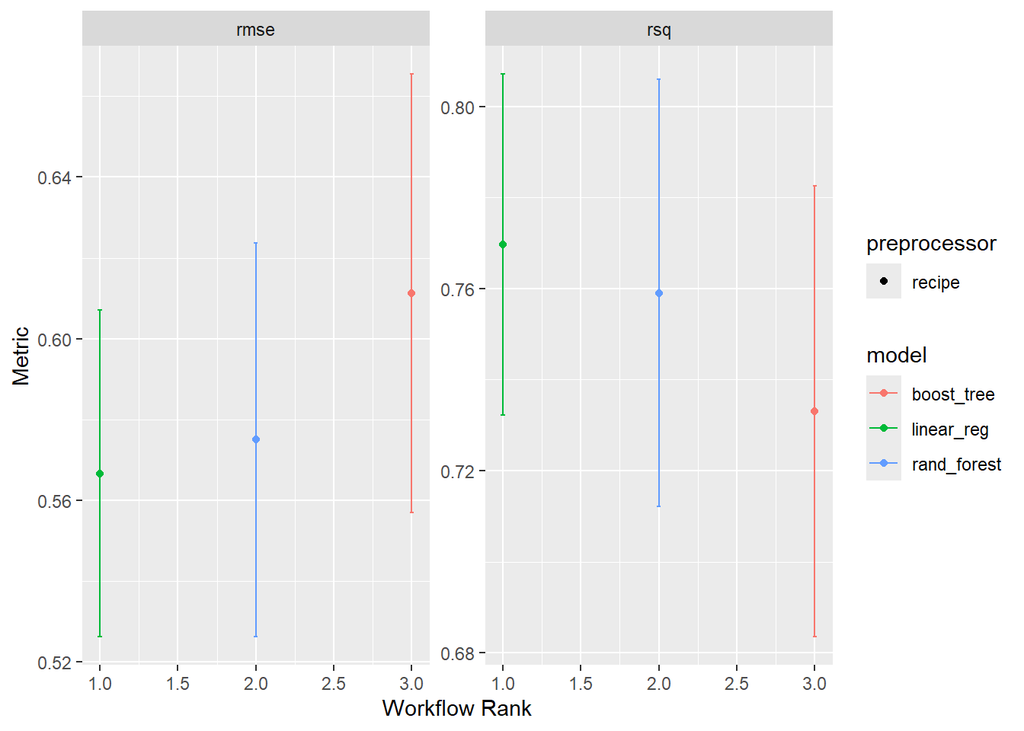

```r
# Use autoplot and rank_results to compare the models.
autoplot(wf2)
```

```r
rank_results(wf2, rank_metric = "rsq", select_best = TRUE)
```

```
# A tibble: 6 × 9
  wflow_id          .config .metric  mean std_err     n preprocessor model  rank
  <chr>             <chr>   <chr>   <dbl>   <dbl> <int> <chr>        <chr> <int>
1 recipe_linear_reg Prepro… rmse    0.567  0.0246    10 recipe       line…     1
2 recipe_linear_reg Prepro… rsq     0.770  0.0228    10 recipe       line…     1
3 recipe_rand_fore… Prepro… rmse    0.575  0.0296    10 recipe       rand…     2
4 recipe_rand_fore… Prepro… rsq     0.759  0.0285    10 recipe       rand…     2
5 recipe_boost_tree Prepro… rmse    0.611  0.0330    10 recipe       boos…     3
6 recipe_boost_tree Prepro… rsq     0.733  0.0302    10 recipe       boos…     3
```

The linear regression model is best out of the three models that were run. This is because the PET_mean and aridity showed more of a linear realationship with the outcome variable of the log Qmean.

Q5f) Extract and Evaluate

```r
#Build a workflow (not workflow set) with your favorite model, recipe, and training data.Use fit to fit all training data to the model

lm_wf2 <- workflow() %>%
  # Add the recipe
  add_recipe(rec2) %>%
  # Add the model
  add_model(lm_model2) %>%
  # Fit the model to the training data
  fit(data = camels_train2)

#Use augment to make predictions on the test data
lm_data2 <- augment(lm_wf2, new_data = camels_test2)
dim(lm_data2)
```

```
[1] 168  61
```

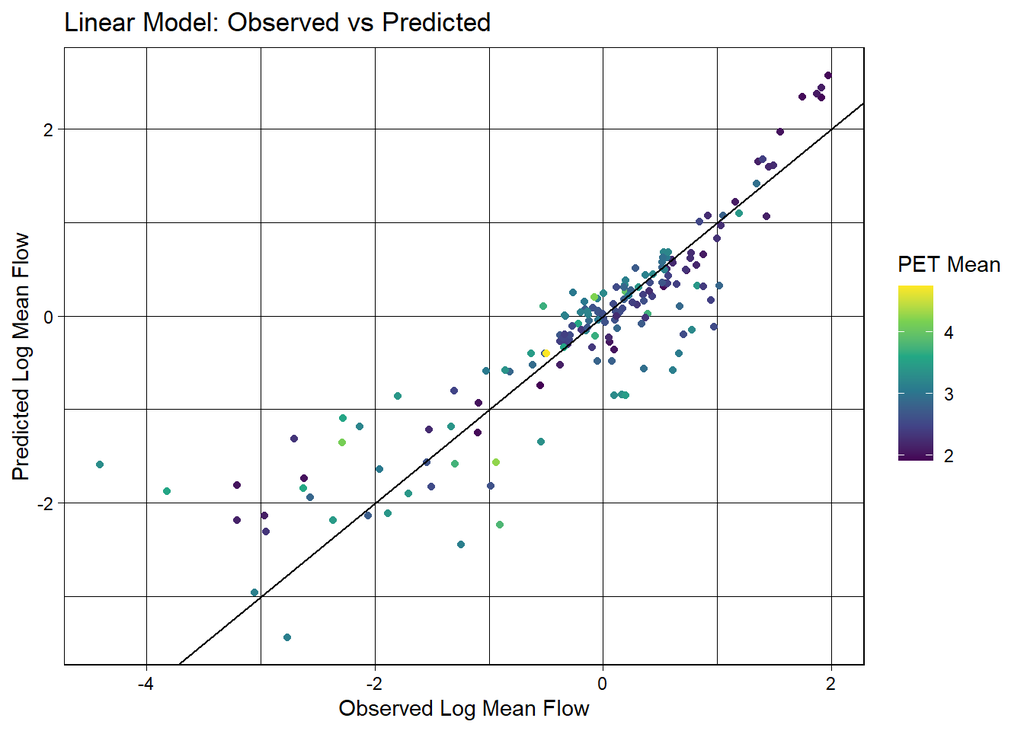

```r
#Create a plot of the observed vs predicted values with clear title, axis labels, and a compelling color scale
ggplot(lm_data2, aes(x = logQmean, y = .pred, colour = pet_mean)) +
  scale_color_viridis_c() +
  geom_point() +
  geom_abline() +
  theme_linedraw() +
  labs(title = "Linear Model: Observed vs Predicted",
       x = "Observed Log Mean Flow",
       y = "Predicted Log Mean Flow",
       color = "PET Mean")
```

```r
#metrics
metrics(lm_data2, truth = logQmean, estimate = .pred)
```

```
# A tibble: 3 × 3
  .metric .estimator .estimate
  <chr>   <chr>          <dbl>
1 rmse    standard       0.532
2 rsq     standard       0.797
3 mae     standard       0.350
```

# Describe what you think of the results

The linear model has a 79% accuracy in estimating the predicted logQmean by the predictor variables. This model shows the linear relationship between the pet_mean predictor variable and the logQmean. The relationship makes sense in the plot and in the metric results. It was also the highest of the other three models tested, so the results make sense.